# Practice_1

Walter J.T.V

2024-09-16

## Dataset

We are going to use the prestige dataset which has 102 rows of dfferent professions and its associated infered prestige percieved by society

```r
rm(list=ls())
library(car)
prestige_df <- Prestige
head(prestige_df)
```

```
##                     education income women prestige census type
## gov.administrators      13.11  12351 11.16     68.8   1113 prof
## general.managers        12.26  25879  4.02     69.1   1130 prof
## accountants             12.77   9271 15.70     63.4   1171 prof
## purchasing.officers     11.42   8865  9.11     56.8   1175 prof
## chemists                14.62   8403 11.68     73.5   2111 prof
## physicists              15.64  11030  5.13     77.6   2113 prof
```

## Univariate outlier detection

The IQR (inter qualite range) is computed IQR = Q3 - Q1

```r
#Remove census column
prestige_df$census <- NULL
names(prestige_df)
```

```
## [1] "education" "income"    "women"     "prestige"  "type"
```

```r
numeric_prestige <- prestige_df[, c("education", "income", "women", "prestige")]
summary(numeric_prestige)
```

```
##    education          income          women           prestige
##  Min.   : 6.380   Min.   :  611   Min.   : 0.000   Min.   :14.80
##  1st Qu.: 8.445   1st Qu.: 4106   1st Qu.: 3.592   1st Qu.:35.23
##  Median :10.540   Median : 5930   Median :13.600   Median :43.60
##  Mean   :10.738   Mean   : 6798   Mean   :28.979   Mean   :46.83
##  3rd Qu.:12.648   3rd Qu.: 8187   3rd Qu.:52.203   3rd Qu.:59.27
##  Max.   :15.970   Max.   :25879   Max.   :97.510   Max.   :87.20
```

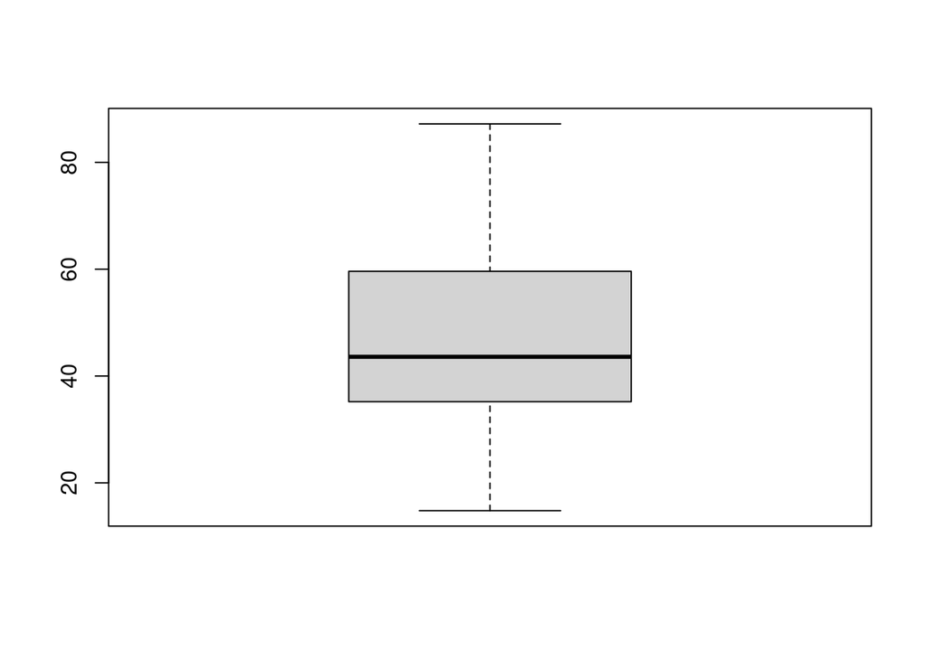

```r
prestige_box <- boxplot(numeric_prestige$prestige) # No mild outliers and no severe outliers either
```

Prestige variable has no outliers, now lets check the average income

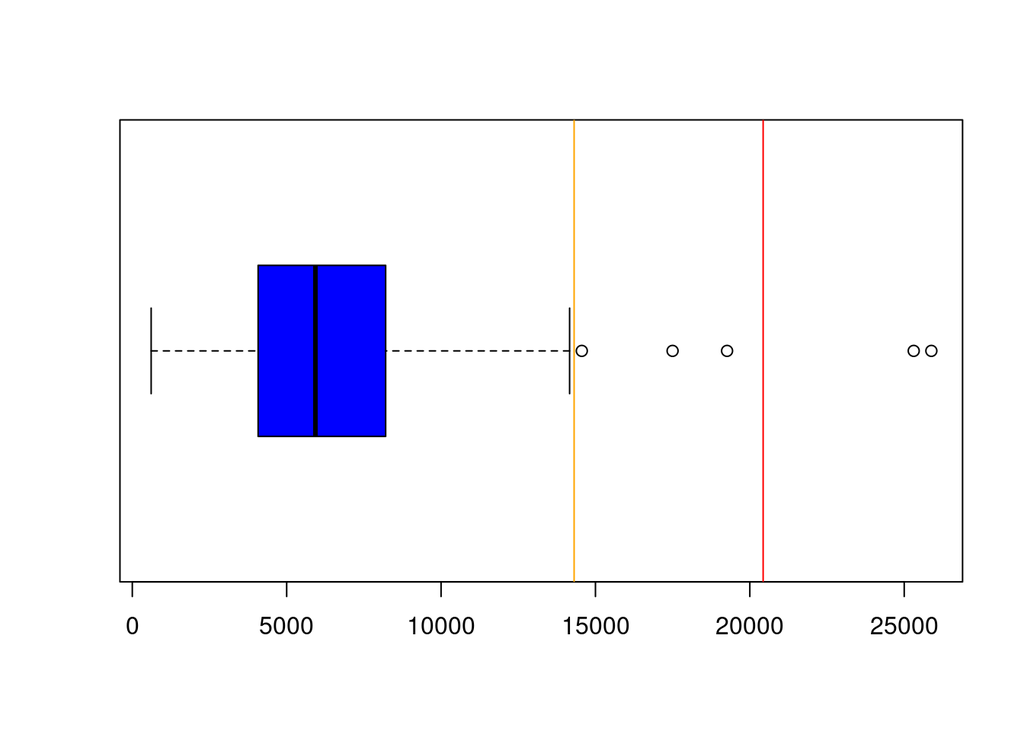

```r
boxplot(numeric_prestige$income, horizontal = T, col= "blue") # There are outliers
income_summary <- summary(numeric_prestige$income)

iqr <- income_summary[5] - income_summary[2]
upmild <- income_summary[5] + 1.5*iqr
upextreme <- income_summary[5] + 3*iqr

boxplot(numeric_prestige$income, horizontal=T, col="blue")
abline(v=upmild, col="orange")
abline(v=upextreme, col="red")
```

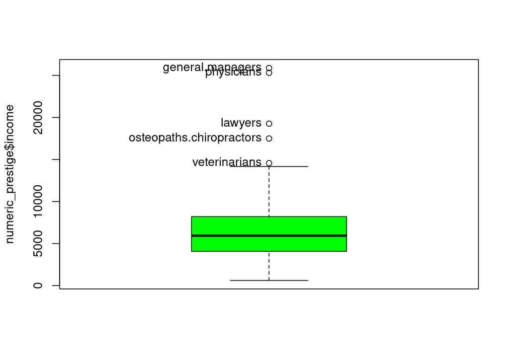

```r
mild_outliers_ids <- which( (prestige_df$income > upmild) & (prestige_df$income < upextreme))

ext_outliers_ids <- which( (prestige_df$income > upextreme))

mild_outliers <- prestige_df[mild_outliers_ids, ]
ext_outliers <- prestige_df[ext_outliers_ids, ]

income_box <- Boxplot(numeric_prestige$income, col="green", id = list(labels=rownames(prestige_df)))
```

```r
income_box
```

```
## [1] "general.managers"         "lawyers"
## [3] "physicians"               "veterinarians"
## [5] "osteopaths.chiropractors"
```

```r
#Range can specify the Quartiles
```

## Multivariate outlier detection

Now we are going to define a distance measure in order to detect **Multivariate outliers** using an iterative algorithm. That is the Mahalanobis distance.

Mahanalobis distances follows a chi-squared distribution, therefore the distance depends in the distance from the center of gravity

```r
  library(chemometrics)
  res.mout <- Moutlier(numeric_prestige, quantile=0.95)
```

[figure not shown]

```
## [1] TRUE
```

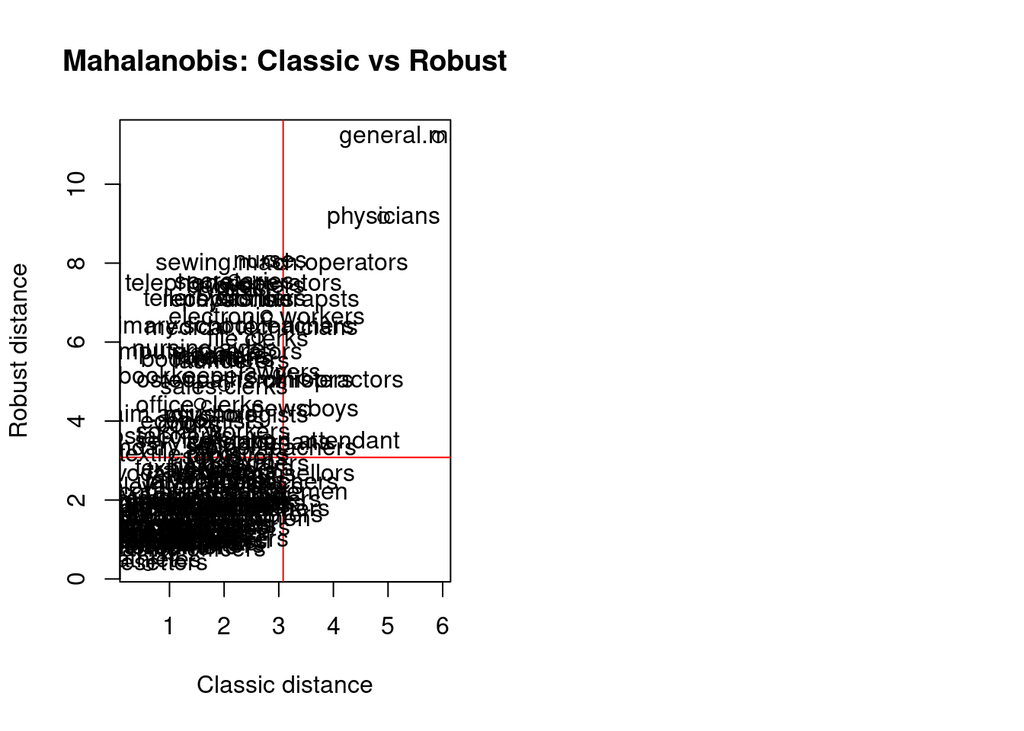

```r
  plot(x=res.mout$md, y=res.mout$rd, main="Mahalanobis: Classic vs Robust", xlab="Classic distance", ylab="Robust distance")
  abline(v=res.mout$cutoff, col="red")
  abline(h=res.mout$cutoff, col="red")
  text(res.mout$md, res.mout$rd, labels=rownames(numeric_prestige))

  mv_outliers <- which( (res.mout$md > res.mout$cutoff) & (res.mout$rd > res.mout$cutoff))

  res.mout$cutoff^2 == qchisq(0.95, 4)
```

## Missing Data Types

There are different kinds of missing data:

- Non-response (All variables are null in an observation)
- Missing values (One or two variables)
- Drop outs (Several missing variables in an observation)

And just removing missing data is bad for the model generalization, but there are 3 procedures:

- Removal of observations with missing data (Bias in results)
- Unconditional mean imputation (HORRIBLE)
- Regression imputation